# Tarea 1

Dalia Camacho

August 14, 2018

En el ejemplo simple que vimos en la sección 1.4, utilizamos una sola muestra de entrenamiento para evaluar el algoritmo. ¿Será posible que escogimos una muestra atípica?

#### 1. Corre el ejemplo con otra muestra y reporta tus resultados de error de entrenamiento y error de prueba para los tres métodos.

Se cargan las librerías necesarias, se define una semilla y la función del ejemplo de la sección 1.2.

```r
library(ggplot2)
# Definir semilla de números aleatorios para reproducibilidad
set.seed(554884)

# Definir función f (desconocida) de la cual se originan los datos verdaderos
f <- function(x){
  ifelse(x < 10, 1000*sqrt(x), 1000*sqrt(10))
}
```

Se generan los datos para la muestra de entrenamiento y datos de prueba:

```r
# Obtener una muestra de la variable x.
# (En el ejemplo eran años de estudio, por eso supuse que podían ser de una distribución poisson)
x             <- rpois(250, 8)
# Encontrar la variable y dada por f(x)+eps
error         <- rnorm(length(x), 0, 500)
y             <- f(x) + error

datos_entrena <- data.frame(x=x[1:50], y=y[1:50])
datos_prueba  <- data.frame(x=x[51:250], y=y[51:250])
```

```r
# Obtener modelo lineal para datos de entrenamiento
mod_lineal   <- lm(y~x, datos_entrena)

#Modelo loess con span de 0.3
mod_loess_03 <- loess(y~x, datos_entrena, span = 0.3)

#Modelo loess con span de 1
mod_loess_1 <- loess(y~x, datos_entrena, span = 1)
```

Graficar los distintos modelos:

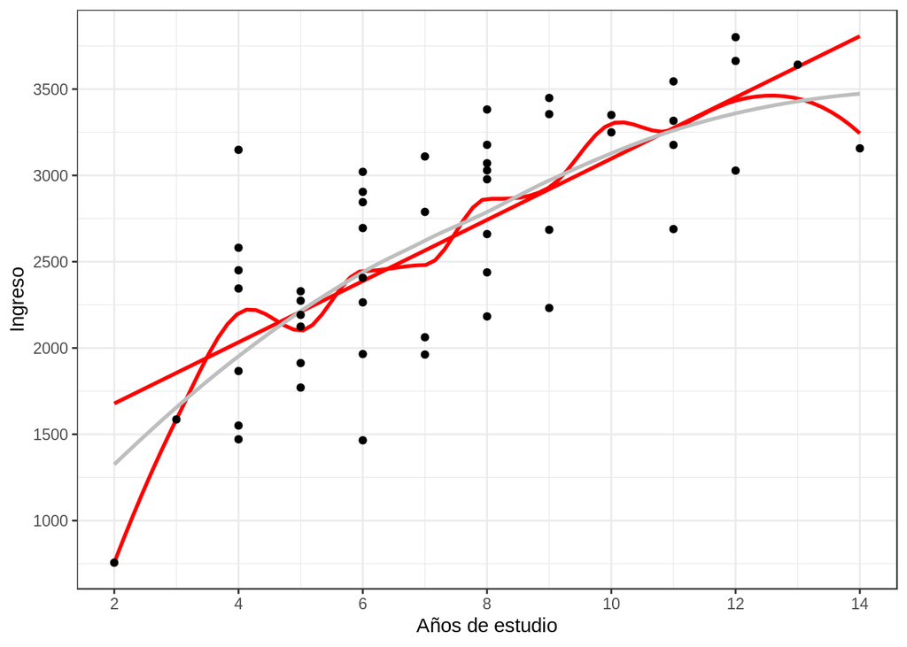

```r
ggplot(datos_entrena, aes(x,y))+
  theme_bw()+
  geom_smooth(method = "lm", se=FALSE, color="red")+
  geom_smooth(method = "loess", span=0.3, se=FALSE, color="red")+
  geom_smooth(method = "loess", span=1, se=FALSE, color="gray")+
  geom_point()+
  xlab("Años de estudio")+
  ylab("Ingreso")+
  scale_y_continuous(breaks = seq(1000, 6000, by=500))+
  scale_x_continuous(breaks = seq(0, 18, by=2))
```

Calcular error de entrenamiento:

```r
# Se obtiene el error de entrenamiento para el modelo lineal
Err_lineal <- sqrt(mean((datos_entrena$y - mod_lineal$fitted.values)^2))

# Se obtiene el error de entrenamiento para el modelo lineal
Err_loess_03 <- sqrt(mean((datos_entrena$y - mod_loess_03$fitted)^2))

# Se obtiene el error de entrenamiento para el modelo lineal
Err_loess_1 <- sqrt(mean((datos_entrena$y - mod_loess_1$fitted)^2))
```

Calcular error de prueba

```r
# Se obtiene el error de prueba para el modelo lineal
Err_pureba_lineal <- sqrt(mean((datos_prueba$y -
                                  predict(mod_lineal,datos_prueba))^2))

# Se obtiene el error de entrenamiento para el modelo lineal
Err_prueba_loess_03 <- sqrt(mean((datos_prueba$y -
                                    predict(mod_loess_03, datos_prueba))^2, na.rm = TRUE))

# Se obtiene el error de entrenamiento para el modelo lineal
Err_prueba_loess_1 <-sqrt(mean((datos_prueba$y -
                                  predict(mod_loess_1, datos_prueba))^2, na.rm = TRUE))
```

Poner errores en un data frame

```r
Errores <- data.frame(cbind(c("Lineal", "Loess 0.3", "Loess 1"),
                            formatC(matrix(c(Err_lineal, Err_pureba_lineal,
                                             Err_loess_03, Err_prueba_loess_03,
                                             Err_loess_1, Err_prueba_loess_1), ncol = 2, byrow = T),
                                    format="f", digits=1)))
names(Errores) <- c("Modelo", "Error de entrenamiento","Error de prueba")
Errores
```

```
##      Modelo Error de entrenamiento Error de prueba
## 1    Lineal                  450.3           546.3
## 2 Loess 0.3                  407.6           536.4
## 3   Loess 1                  435.5           515.2
```

#### 2. Opcional (difícil): evalúa los tres métodos comparando estos valores para un número grande de distintas simulaciones de los datos de entrenamiento.

Definir número de simulaciones y tamaño de conjuntos de prueba y entrenamiento

```r
# Número de simulaciones
Nsim           <- 100
# Tamaño del conjunto de entrenamiento
Nentrena <- 1000
# Tamaño de conjunto de prueba
Nprueba        <- 1000
```

Loop para generar errores de prueba para distintas muestras

```r
# Definir vectores con errores de prueba y entrenamiento
Errores_lineal   <- c()
Errores_loess_03 <- c()
Errores_loess_1  <- c()

Errores_prueba_lineal   <- c()
Errores_prueba_loess_03 <- c()
Errores_prueba_loess_1  <- c()

for (i in 1:Nsim) {
  # Obtener una muestra de la variable x.
  # Debido a warnings cambio la distribución de poisson a gamma
  x             <- rgamma(Nentrena+Nprueba, 8,1)

  # Encontrar la variable y dada por f(x)+eps
  error         <- rnorm(length(x), 0, 500)
  y             <- f(x) + error

  datos_entrena <- data.frame(x=x[1:Nentrena], y=y[1:Nentrena])
  datos_prueba  <- data.frame(x=x[(Nentrena+1):(Nentrena+Nprueba)],
                              y=y[(Nentrena+1):(Nentrena+Nprueba)])

  # Obtener modelo lineal para datos de entrenamiento
  mod_lineal   <- lm(y~x, datos_entrena)

  #Modelo loess con span de 0.3
  mod_loess_03 <- loess(y~x, datos_entrena, span = 0.3)

  #Modelo loess con span de 1
  mod_loess_1 <- loess(y~x, datos_entrena, span = 1)

  # Se obtiene el error de entrenamiento para el modelo lineal
  Errores_lineal <- c(Errores_lineal, sqrt(mean((datos_entrena$y - mod_lineal$fitted.values)^2)))

  # Se obtiene el error de entrenamiento para el modelo lineal
  Errores_loess_03 <- c(Errores_loess_03, sqrt(mean((datos_entrena$y - mod_loess_03$fitted)^2)))

  # Se obtiene el error de entrenamiento para el modelo lineal
  Errores_loess_1 <- c(Errores_loess_1,sqrt(mean((datos_entrena$y - mod_loess_1$fitted)^2)))

  # Se obtiene el error de prueba para el modelo lineal
  Errores_prueba_lineal <-c(Errores_prueba_lineal,
                            sqrt(mean((datos_prueba$y -
                                         predict(mod_lineal,datos_prueba))^2)))

  # Se obtiene el error de entrenamiento para el modelo lineal
  Errores_prueba_loess_03 <-c(Errores_prueba_loess_03,
                              sqrt(mean((datos_prueba$y -
                                           predict(mod_loess_03, datos_prueba))^2,
                                        na.rm = TRUE)))

  # Se obtiene el error de entrenamiento para el modelo lineal
  Errores_prueba_loess_1 <-c(Errores_prueba_loess_1,
                             sqrt(mean((datos_prueba$y - predict(mod_loess_1, datos_prueba))^2, na.rm = TRUE)))



}
```

Graficar errores

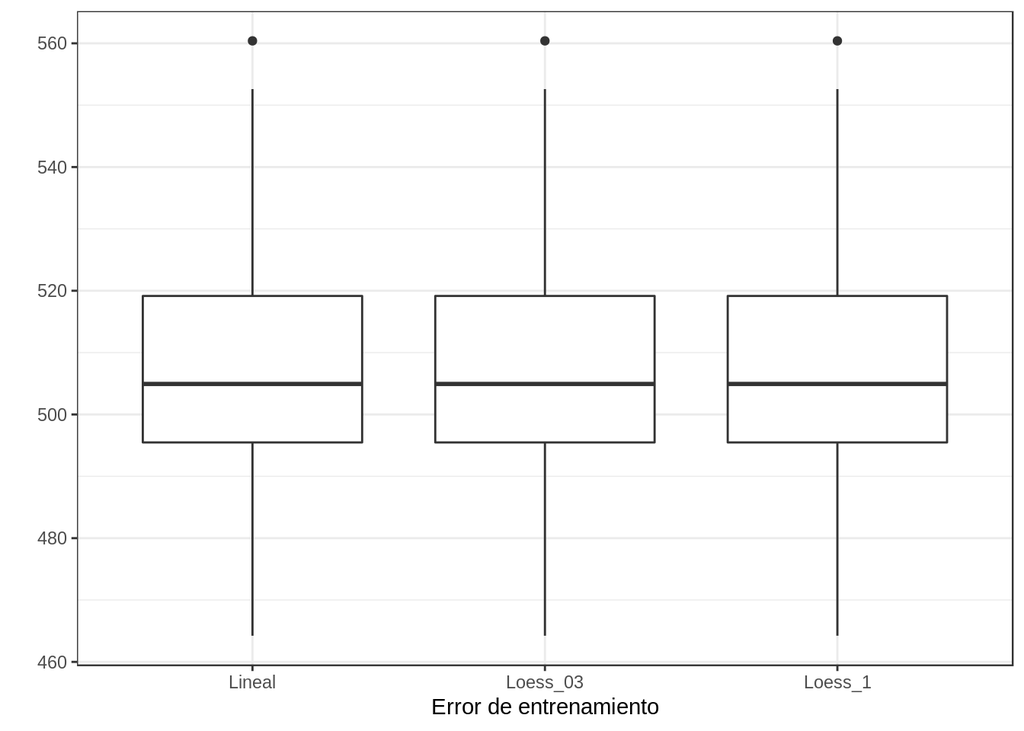

```r
ERR_data <- data.frame(cbind(c(rep("Lineal", 3*Nsim), rep("Loess_03", 3*Nsim),
                               rep("Loess_1",3*Nsim)),
                             c(Errores_lineal, Errores_loess_03, Errores_loess_1),
                             c(Errores_prueba_lineal, Errores_prueba_loess_03,
                               Errores_prueba_loess_1)))
names(ERR_data) <- c("Modelo", "Error_entrena", "Error_prueba")
ggplot(ERR_data, aes(Modelo, as.numeric(as.character(Error_entrena))))+
  theme_bw()+
  geom_boxplot()+
  xlab("Error de entrenamiento")+
  ylab("")
```

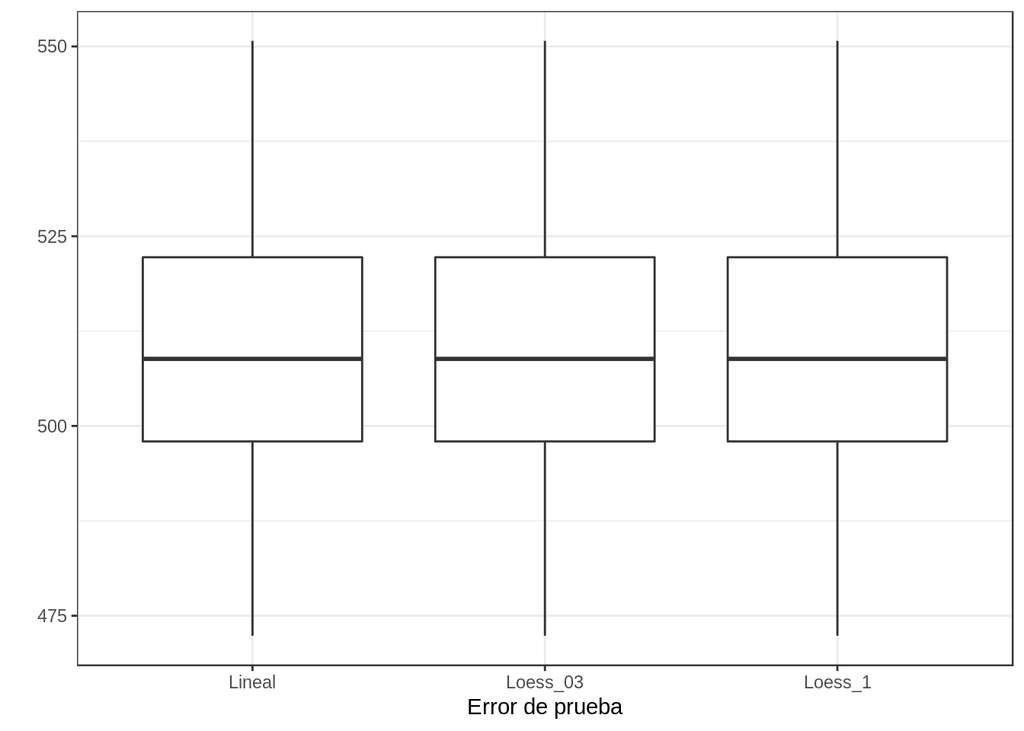

```r
ggplot(ERR_data, aes(Modelo, as.numeric(as.character(Error_prueba))))+
  theme_bw()+
  geom_boxplot()+
  xlab("Error de prueba")+
  ylab("")
```